# Project03

Gabriel Santos

2022-10-21

# The question, “Which are the most valued data science skills?”

## Data Source

Data from [Kaggle.com](https://www.kaggle.com/discdiver/the-most-in-demand-skills-for-data-scientists/)

## Libraries load

```r
library(tidyverse)
library(knitr)
library(kableExtra)
library(tm)
library(wordcloud)
library(memoise)
library(SnowballC)
library(RColorBrewer)
library(RCurl)
library(XML)
library(treemap)
```

## Data Load

### Data read from the CSV file which was uploaded to Github.

```r
url <- "https://raw.githubusercontent.com/GabrielSantos33/DATA607_Project_03/main/DataSkills.csv"
data_skills <-read.csv(url, stringsAsFactors = FALSE)
kable(data_skills) %>% kable_styling(bootstrap_options = "striped")
```

| Keyword | LinkedIn | Indeed | SimplyHired | Monster |
| --- | --- | --- | --- | --- |
| machine learning | 5,701 | 3,439 | 2,561 | 2,340 |
| analysis | 5,168 | 3,500 | 2,668 | 3,306 |
| statistics | 4,893 | 2,992 | 2,308 | 2,399 |
| computer science | 4,517 | 2,739 | 2,093 | 1,900 |
| communication | 3,404 | 2,344 | 1,791 | 2,053 |
| mathematics | 2,605 | 1,961 | 1,497 | 1,815 |
| visualization | 1,879 | 1,413 | 1,153 | 1,207 |
| AI composite | 1,568 | 1,125 | 811 | 687 |
| deep learning | 1,310 | 979 | 675 | 606 |
| NLP composite | 1,212 | 910 | 660 | 582 |
| software development | 732 | 627 | 481 | 784 |
| neural networks | 671 | 485 | 421 | 305 |
| data engineering | 514 | 339 | 276 | 200 |
| project management | 476 | 397 | 330 | 348 |
| software engineering | 413 | 295 | 250 | 512 |
| Total | 35,063 | 23,545 | 17,975 | 19,044 |
| add AI and artificial intelligence and subtract the overlap search term with both terms in it |  |  |  |  |
| AI | 916 | 690 | 508 | 680 |
| artificial intelligence | 964 | 754 | 498 | 679 |
| AI + artificial intelligence | 312 | 319 | 195 | 672 |
| add NLP and natural language processing and subtract the overlap search term with both terms in it |  |  |  |  |
| NLP | 643 | 466 | 362 | 576 |
| natural language processing | 791 | 621 | 429 | 575 |
| NLP + natural language processing | 222 | 177 | 131 | 569 |
| “data scientist” “[keyword]” |  |  |  |  |
| Oct 10, 2018 |  |  |  |  |

# Tidy and Wrangle

## Data Structure

### Structure of the dataset.

```r
str(data_skills)
```

```
## 'data.frame':    30 obs. of  5 variables:
##  $ Keyword    : chr  "machine learning" "analysis" "statistics" "computer science" ...
##  $ LinkedIn   : chr  "5,701" "5,168" "4,893" "4,517" ...
##  $ Indeed     : chr  "3,439" "3,500" "2,992" "2,739" ...
##  $ SimplyHired: chr  "2,561" "2,668" "2,308" "2,093" ...
##  $ Monster    : chr  "2,340" "3,306" "2,399" "1,900" ...
```

## Data Types

### Removed commas in the numbers and changed the data types from character to numeric for the following columns: LinkedIn, Indeed, SimplyHired and Monster.

```r
data_skills$LinkedIn <- str_replace_all(data_skills$LinkedIn, ",", "") %>% as.numeric()
data_skills$Indeed <- str_replace_all(data_skills$Indeed, ",", "") %>% as.numeric()
data_skills$SimplyHired <- str_replace_all(data_skills$SimplyHired, ",", "") %>% as.numeric()
data_skills$Monster <- str_replace_all(data_skills$Monster, ",", "") %>% as.numeric()
str(data_skills)
```

```
## 'data.frame':    30 obs. of  5 variables:
##  $ Keyword    : chr  "machine learning" "analysis" "statistics" "computer science" ...
##  $ LinkedIn   : num  5701 5168 4893 4517 3404 ...
##  $ Indeed     : num  3439 3500 2992 2739 2344 ...
##  $ SimplyHired: num  2561 2668 2308 2093 1791 ...
##  $ Monster    : num  2340 3306 2399 1900 2053 ...
```

## Data Subset

### Removed the rows by sub-setting and eliminating those in which LinkedIn was NA; removed “Total”.

```r
data_skills_subset <- subset(data_skills, !is.na(LinkedIn)) %>% subset(!Keyword == "Total")
kable(data_skills_subset) %>% kable_styling(bootstrap_options = "striped")
```

|  | Keyword | LinkedIn | Indeed | SimplyHired | Monster |
| --- | --- | --- | --- | --- | --- |
| 1 | machine learning | 5701 | 3439 | 2561 | 2340 |
| 2 | analysis | 5168 | 3500 | 2668 | 3306 |
| 3 | statistics | 4893 | 2992 | 2308 | 2399 |
| 4 | computer science | 4517 | 2739 | 2093 | 1900 |
| 5 | communication | 3404 | 2344 | 1791 | 2053 |
| 6 | mathematics | 2605 | 1961 | 1497 | 1815 |
| 7 | visualization | 1879 | 1413 | 1153 | 1207 |
| 8 | AI composite | 1568 | 1125 | 811 | 687 |
| 9 | deep learning | 1310 | 979 | 675 | 606 |
| 10 | NLP composite | 1212 | 910 | 660 | 582 |
| 11 | software development | 732 | 627 | 481 | 784 |
| 12 | neural networks | 671 | 485 | 421 | 305 |
| 13 | data engineering | 514 | 339 | 276 | 200 |
| 14 | project management | 476 | 397 | 330 | 348 |
| 15 | software engineering | 413 | 295 | 250 | 512 |
| 20 | AI | 916 | 690 | 508 | 680 |
| 21 | artificial intelligence | 964 | 754 | 498 | 679 |
| 22 | AI + artificial intelligence | 312 | 319 | 195 | 672 |
| 25 | NLP | 643 | 466 | 362 | 576 |
| 26 | natural language processing | 791 | 621 | 429 | 575 |
| 27 | NLP + natural language processing | 222 | 177 | 131 | 569 |

## Create new columns

### Crated a new column `Total_Mention`.`Total_Mention` was calculated by adding all numbers from the 4 jobboards for each skill.

```r
data_skills_2 <- data_skills_subset %>% mutate(Total_Mention = LinkedIn + Indeed + SimplyHired + Monster)
kable(data_skills_2) %>% kable_styling(bootstrap_options = "striped")
```

|  | Keyword | LinkedIn | Indeed | SimplyHired | Monster | Total_Mention |
| --- | --- | --- | --- | --- | --- | --- |
| 1 | machine learning | 5701 | 3439 | 2561 | 2340 | 14041 |
| 2 | analysis | 5168 | 3500 | 2668 | 3306 | 14642 |
| 3 | statistics | 4893 | 2992 | 2308 | 2399 | 12592 |
| 4 | computer science | 4517 | 2739 | 2093 | 1900 | 11249 |
| 5 | communication | 3404 | 2344 | 1791 | 2053 | 9592 |
| 6 | mathematics | 2605 | 1961 | 1497 | 1815 | 7878 |
| 7 | visualization | 1879 | 1413 | 1153 | 1207 | 5652 |
| 8 | AI composite | 1568 | 1125 | 811 | 687 | 4191 |
| 9 | deep learning | 1310 | 979 | 675 | 606 | 3570 |
| 10 | NLP composite | 1212 | 910 | 660 | 582 | 3364 |
| 11 | software development | 732 | 627 | 481 | 784 | 2624 |
| 12 | neural networks | 671 | 485 | 421 | 305 | 1882 |
| 13 | data engineering | 514 | 339 | 276 | 200 | 1329 |
| 14 | project management | 476 | 397 | 330 | 348 | 1551 |
| 15 | software engineering | 413 | 295 | 250 | 512 | 1470 |
| 20 | AI | 916 | 690 | 508 | 680 | 2794 |
| 21 | artificial intelligence | 964 | 754 | 498 | 679 | 2895 |
| 22 | AI + artificial intelligence | 312 | 319 | 195 | 672 | 1498 |
| 25 | NLP | 643 | 466 | 362 | 576 | 2047 |
| 26 | natural language processing | 791 | 621 | 429 | 575 | 2416 |
| 27 | NLP + natural language processing | 222 | 177 | 131 | 569 | 1099 |

## Add rows

### Added rows “AI” and “Artificial Intelligence” then subtracted the overlapping skills. We assigned the values to “AI + Artificial Intelligence”.

```r
data_skills_2[18,2:6] <- data_skills_2[16,2:6] + data_skills_2[17,2:6] - data_skills_2[18,2:6]
```

### Add new rows “NLP” and “Natural Language Processing” then subtracted the overlapping skills. We assigned the values to “NLP + Natural Language Processing”.

```r
data_skills_2[21,2:6] <- data_skills_2[19,2:6] + data_skills_2[20,2:6] - data_skills_2[21,2:6]
```

## Remove rows

### Removed the unnecessary rows “AI”, “Artificial Intelligence”, “NLP” and “Natural Language Processing”.

```r
data_skills_tidy <- data_skills_2[- c(16, 17, 19, 20), ]
```

### Using mutuate function on the data frame to generate another new column `Percentage`.Percentage was calculated by dividing the total number of each skill by the overall total of all skills.

```r
data_skills_tidy <- data_skills_tidy %>% mutate(Percentage = Total_Mention/sum(Total_Mention))
```

# Analysis and Visualization

## Bar Plot

### Created a bar plot to show the total frequency of each data science skill mentioned in the jobboards, ranked from highest to lowest.

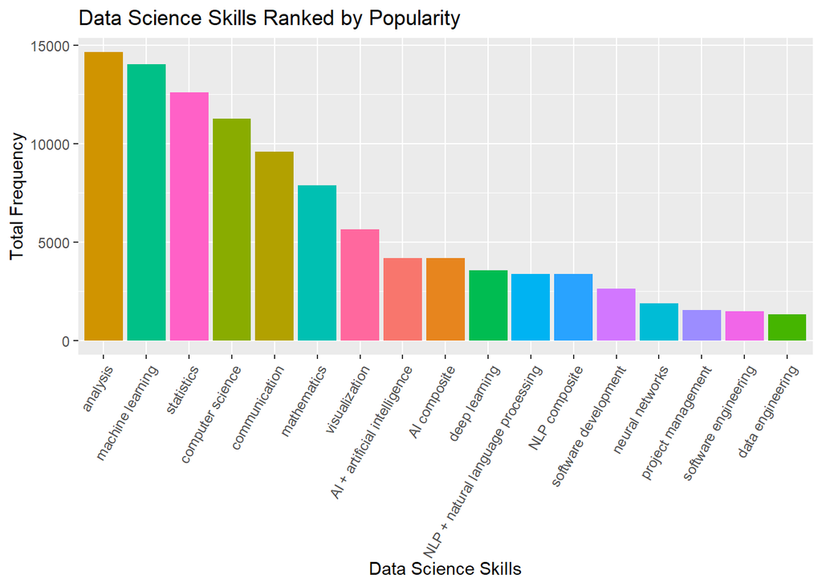

## Treemap

### Create a treemap to show the percentage of each data science skill in respect to total.

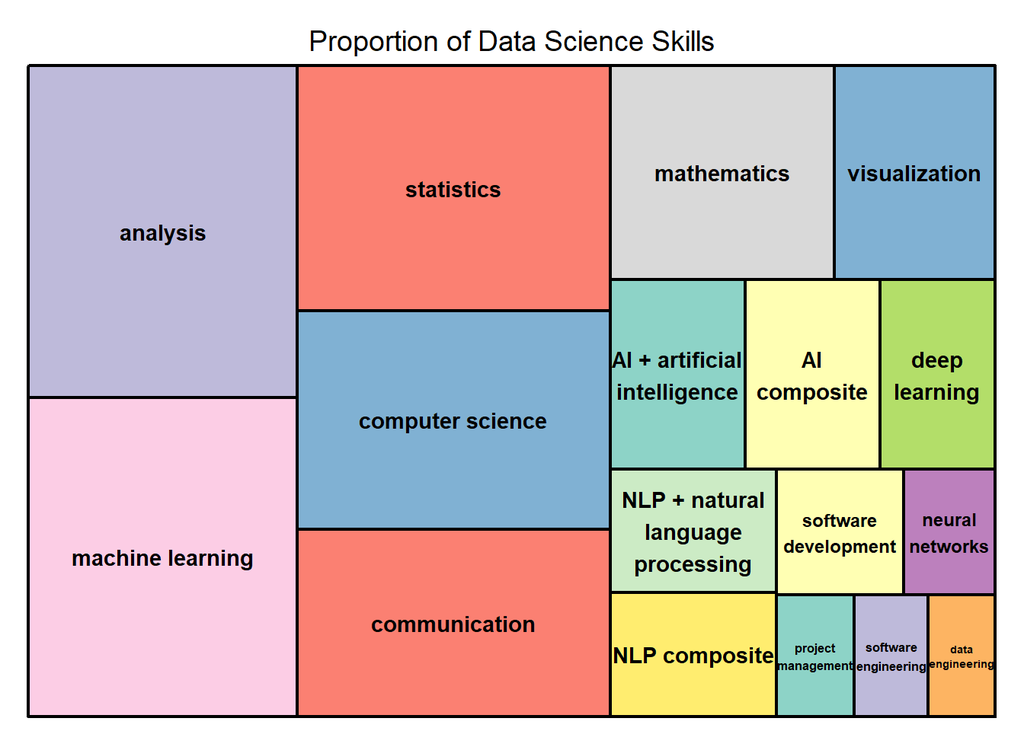

## Word Cloud

### Determine the most popular words in the data set.

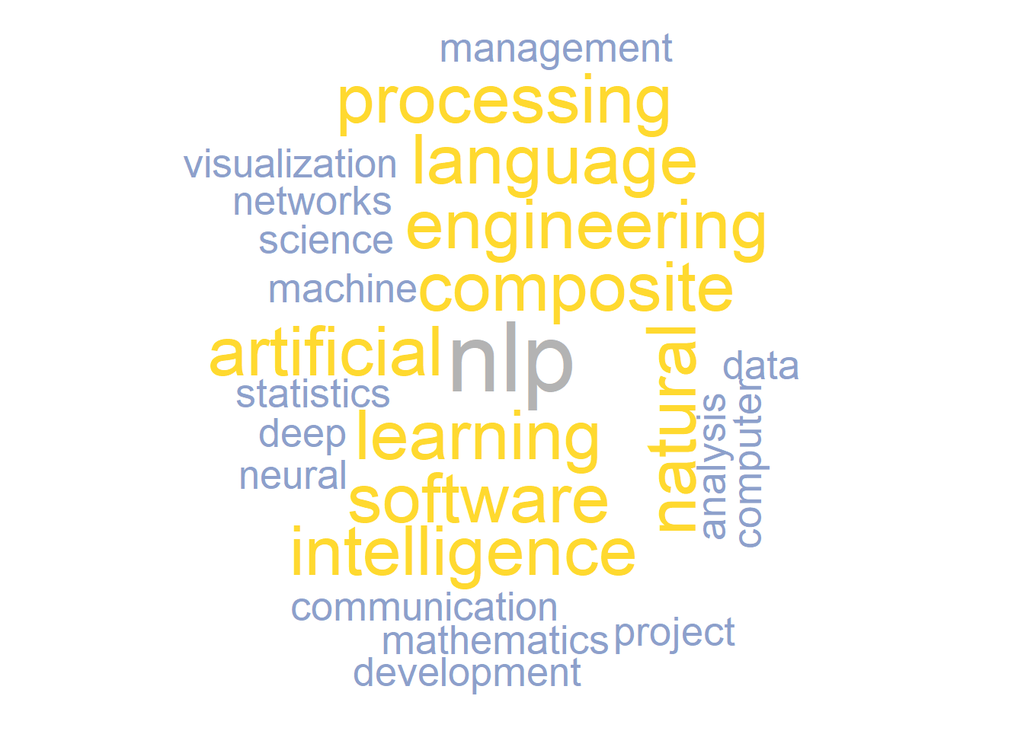

## Conclusions

### The top five keyword/skills mentioned by post throughout the different platforms were *Analysis*, *Machine Learning*, *Statistics*, *Computer Science* and *Communication*. These keywords/skills ranked differently across platforms.

In LinkedIn, the rank was as follows: *Machine Learning*, *Analysis*, *Statistics*, *Computer Science* and *Communication*. In Indeed and Simply Hired, the rank was as follows: *Analysis*, *Machine Learning*, *Statistics*, *Computer Science* and *Communication*. In Monster, the rank was as follows: *Analysis*, *Statistics*, *Machine Learning*, *Communication* and *Computer Science*.